# motifbreakR: an Introduction

Simon G. Coetzee, Gerhard A. Coetzee and Dennis J. Hazelett

2016-02-24

# 1 Introduction

This document offers an introduction and overview of *motifBreakR*, which allows the biologist to judge whether the sequence surrounding a polymorphism or mutation is a good match to known transcription factor binding sites, and how much information is gained or lost in one allele of the polymorphism relative to another or mutation vs. wildtype. *motifBreakR* is flexible, giving a choice of algorithms for interrogation of genomes with motifs from public sources that users can choose from; these are 1) a weighted-sum, 2) log-probabilities, and 3) relative entropy. *motifBreakR* can predict effects for novel or previously described variants in public databases, making it suitable for tasks beyond the scope of its original design. Lastly, it can be used to interrogate any genome curated within Bioconductor.

*motifBreakR* works with position probability matrices (PPM). PPM are derived as the fractional occurrence of nucleotides A,C,G, and T at each position of a position frequency matrix (PFM). PFM are simply the tally of each nucleotide at each position across a set of aligned sequences. With a PPM, one can generate probabilities based on the genome, or more practically, create any number of position specific scoring matrices (PSSM) based on the principle that the PPM contains information about the likelihood of observing a particular nucleotide at a particular position of a true transcription factor binding site.

This guide includes a brief overview of the processing flow, an example focusing more in depth on the practical aspect of using *motifBreakR*, and finally a detailed section on the scoring methods employed by the package.

# 2 Processing overview

*motifBreakR* may be used to interrogate SNPs or SNVs for their potential effect on transcription factor binding by examining how the two alleles of the variant effect the binding score of a motif. The basic process is outlined in the figure below.

## 2.1 Outline of process

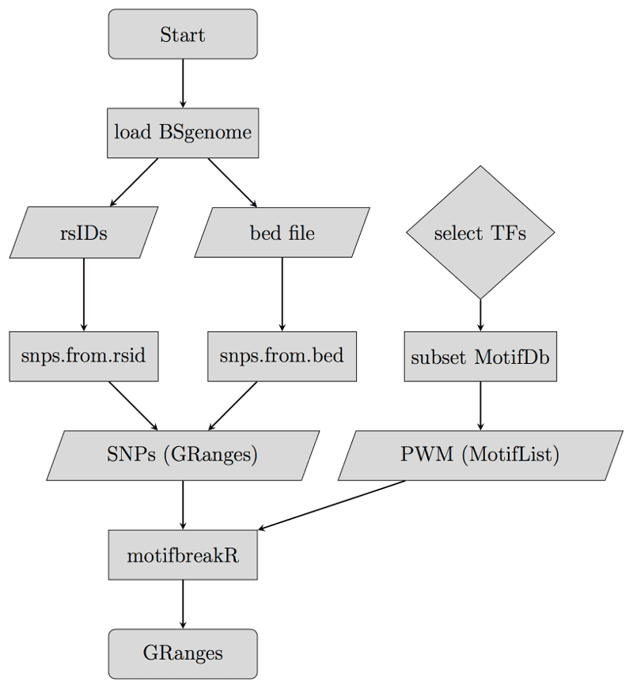

*motifbreakR workflow: How inputs (trapezoids) are generated from R functions (rectangles). Diamonds represent decisions of the user.*

Practically *motifBreakR* has involves three phases.

1. *Read in Single Nucleotide Variants:* The first step is to read in the list of variants. Variants can be a list of rsIDs if your SNPs are represented in one of the SNPlocs packages, may be included as a [.bed](http://www.genome.ucsc.edu/FAQ/FAQformat.html#format1) file with a specifically formatted name field, or may be provided as a [.vcf](http://www.1000genomes.org/wiki/analysis/variant%20call%20format/vcf-variant-call-format-version-41) file. We then transform these input such that it may be read my *motifBreakR*.
2. *Find Broken Motifs:* Next we present *motifBreakR* with the input generated in the previous step, along with a set of motifs formatted as class `MotifList`, and your preferred scoring method.
3. *Visualize SNPs and motifs:* Finally we can visualize which motifs are broken by any individual SNP using our plotting function.

# 3 How To Use motifbreakR: A Practical Example

This section offers an example of how to use *motifBreakR* to identify potentially disrupted transcription factor binding sites due to 701 SNPs output from a *[FunciSNP](http://bioconductor.org/packages/release/bioc/html/FunciSNP.html)* analysis of Prostate Cancer (PCa) genome wide association studies (GWAS) risk loci. The SNPs are included in this package here:

```r
library(motifbreakR)
pca.snps.file <- system.file("extdata", "pca.enhancer.snps", package = "motifbreakR")
pca.snps <- as.character(read.table(pca.snps.file)[,1])
```

The simplest form of a *motifBreakR* analysis is summarized as follows:

```r
variants <- snps.from.rsid(rsid = pca.snps,
                           dbSNP = SNPlocs.Hsapiens.dbSNP142.GRCh37,
                           search.genome = BSgenome.Hsapiens.UCSC.hg19)
motifbreakr.results <- motifbreakR(snpList = variants, pwmList = MotifDb, threshold = 0.9)
plotMB(results = motifbreakr.results, rsid = "rs7837328", effect = "strong")
```

Lets look at these steps more closely and see how we can customize our analysis.

## 3.1 *Step 1* | Read in Single Nucleotide Variants

Variants can be input either as a list of rsIDs or as a [.bed](http://www.genome.ucsc.edu/FAQ/FAQformat.html#format1) file. The main factor determining which you will use is if your variants have rsIDs that are included in one of the Bioconductor `SNPlocs` packages. The present selection is seen here:

```r
library(BSgenome)
available.SNPs()
```

```
##  [1] "SNPlocs.Hsapiens.dbSNP.20090506"      "SNPlocs.Hsapiens.dbSNP.20100427"
##  [3] "SNPlocs.Hsapiens.dbSNP.20101109"      "SNPlocs.Hsapiens.dbSNP.20110815"
##  [5] "SNPlocs.Hsapiens.dbSNP.20111119"      "SNPlocs.Hsapiens.dbSNP.20120608"
##  [7] "SNPlocs.Hsapiens.dbSNP141.GRCh38"     "SNPlocs.Hsapiens.dbSNP142.GRCh37"
##  [9] "SNPlocs.Hsapiens.dbSNP144.GRCh37"     "SNPlocs.Hsapiens.dbSNP144.GRCh38"
## [11] "XtraSNPlocs.Hsapiens.dbSNP141.GRCh38" "XtraSNPlocs.Hsapiens.dbSNP144.GRCh37"
## [13] "XtraSNPlocs.Hsapiens.dbSNP144.GRCh38"
```

For cases where your rsIDs are not available in a SNPlocs package, or you have novel variants that are not cataloged at all, variants may be entered in [BED](http://www.genome.ucsc.edu/FAQ/FAQformat.html#format1) format as seen below:

```r
snps.file <- system.file("extdata", "snps.bed", package = "motifbreakR")
read.delim(snps.file, header = FALSE)
```

```
##     V1        V2        V3                V4 V5 V6
## 1 chr2  12581137  12581138        rs10170896  0  +
## 2 chr2  12594017  12594018 chr2:12594018:G:A  0  +
## 3 chr3 192388677 192388678        rs13068005  0  +
## 4 chr4 122361479 122361480        rs12644995  0  +
## 5 chr6  44503245  44503246 chr6:44503246:A:T  0  +
## 6 chr6  44503247  44503248 chr6:44503248:G:C  0  +
## 7 chr6  85232897  85232898         rs4510639  0  +
## 8 chr6  44501872  44501873          rs932680  0  +
```

Our requirements for the BED file are that it must include `chromosome`, `start`, `end`, `name`, `score` and `strand` fields – where the name field is required to be in one of two formats, either an rsID that is present in a SNPlocs package, or in the form `chromosome:position:referenceAllele:alternateAllele` e.g., `chr2:12594018:G:A`. It is also essential that the fields are TAB separated, not a mixture of tabs and spaces.

More to the point here are the two methods for reading in the variants.

### 3.1.1 SNPs from rsID:

This first way of importing variants uses the PCa SNPs we found above `pca.snps`.

We use the *[SNPlocs.Hsapiens.dbSNP142.GRCh37](http://bioconductor.org/packages/release/data/annotation/html/SNPlocs.Hsapiens.dbSNP142.GRCh37.html)* which is the SNP locations and alleles defined in [dbSNP142](http://www.ncbi.nlm.nih.gov/projects/SNP/snp_summary.cgi?view+summary=view+summary&build_id=142) as a source for looking up our rsIDs and *[BSgenome.Hsapiens.UCSC.hg19](http://bioconductor.org/packages/release/data/annotation/html/BSgenome.Hsapiens.UCSC.hg19.html)* which holds the reference sequence for [UCSC genome build hg19](http://www.ncbi.nlm.nih.gov/assembly/2758/). Additional SNPlocs packages are availble from Bioconductor.

```r
library(SNPlocs.Hsapiens.dbSNP142.GRCh37) # dbSNP137 in hg19
library(BSgenome.Hsapiens.UCSC.hg19)     # hg19 genome
head(pca.snps)
```

```
## [1] "rs1551515"  "rs1551513"  "rs17762938" "rs4473999"  "rs7823297"  "rs9656964"
```

```r
snps.mb <- snps.from.rsid(rsid = pca.snps,
                          dbSNP = SNPlocs.Hsapiens.dbSNP142.GRCh37,
                          search.genome = BSgenome.Hsapiens.UCSC.hg19)
snps.mb
```

```
## GRanges object with 700 ranges and 4 metadata columns:
##              seqnames                 ranges strand   |      SNP_id alleles_as_ambig            REF
##                 <Rle>              <IRanges>  <Rle>   | <character>   <DNAStringSet> <DNAStringSet>
##   rs10007915     chr4 [106065308, 106065308]      +   |  rs10007915                S              C
##   rs10015716     chr4 [ 95548550,  95548550]      +   |  rs10015716                R              G
##   rs10034824     chr4 [ 95524838,  95524838]      +   |  rs10034824                K              G
##   rs10056823     chr5 [115609454, 115609454]      +   |  rs10056823                S              C
##    rs1006140    chr19 [ 38778915,  38778915]      +   |   rs1006140                R              A
##          ...      ...                    ...    ... ...         ...              ...            ...
##    rs9901746    chr17 [ 36103149,  36103149]      +   |   rs9901746                R              G
##    rs9908087    chr17 [ 69106937,  69106937]      +   |   rs9908087                K              T
##     rs991429    chr17 [ 69109773,  69109773]      +   |    rs991429                R              G
##    rs9973650     chr2 [238380266, 238380266]      +   |   rs9973650                R              G
##     rs998071     chr4 [ 95591976,  95591976]      +   |    rs998071                S              C
##                         ALT
##              <DNAStringSet>
##   rs10007915              G
##   rs10015716              A
##   rs10034824              T
##   rs10056823              G
##    rs1006140              G
##          ...            ...
##    rs9901746              A
##    rs9908087              G
##     rs991429              A
##    rs9973650              A
##     rs998071              G
##   -------
##   seqinfo: 93 sequences (1 circular) from hg19 genome
```

```r
library(BSgenome)
genomes <- available.genomes()
length(genomes)
```

```
## [1] 82
```

```r
genomes
```

```
##  [1] "BSgenome.Alyrata.JGI.v1"                   "BSgenome.Amellifera.BeeBase.assembly4"
##  [3] "BSgenome.Amellifera.UCSC.apiMel2"          "BSgenome.Amellifera.UCSC.apiMel2.masked"
##  [5] "BSgenome.Athaliana.TAIR.04232008"          "BSgenome.Athaliana.TAIR.TAIR9"
##  [7] "BSgenome.Btaurus.UCSC.bosTau3"             "BSgenome.Btaurus.UCSC.bosTau3.masked"
##  [9] "BSgenome.Btaurus.UCSC.bosTau4"             "BSgenome.Btaurus.UCSC.bosTau4.masked"
## [11] "BSgenome.Btaurus.UCSC.bosTau6"             "BSgenome.Btaurus.UCSC.bosTau6.masked"
## [13] "BSgenome.Btaurus.UCSC.bosTau8"             "BSgenome.Celegans.UCSC.ce10"
## [15] "BSgenome.Celegans.UCSC.ce2"                "BSgenome.Celegans.UCSC.ce6"
## [17] "BSgenome.Cfamiliaris.UCSC.canFam2"         "BSgenome.Cfamiliaris.UCSC.canFam2.masked"
## [19] "BSgenome.Cfamiliaris.UCSC.canFam3"         "BSgenome.Cfamiliaris.UCSC.canFam3.masked"
## [21] "BSgenome.Dmelanogaster.UCSC.dm2"           "BSgenome.Dmelanogaster.UCSC.dm2.masked"
## [23] "BSgenome.Dmelanogaster.UCSC.dm3"           "BSgenome.Dmelanogaster.UCSC.dm3.masked"
## [25] "BSgenome.Dmelanogaster.UCSC.dm6"           "BSgenome.Drerio.UCSC.danRer10"
## [27] "BSgenome.Drerio.UCSC.danRer5"              "BSgenome.Drerio.UCSC.danRer5.masked"
## [29] "BSgenome.Drerio.UCSC.danRer6"              "BSgenome.Drerio.UCSC.danRer6.masked"
```

[output cut: 26 more lines]

### 3.1.2 SNPs from BED formatted file:

Here we examine two possibilities. In one case we have a mixture of rsIDs and our naming scheme that allows for arbitrary variants. Second we have a list of variants for the zebrafish *Danio rerio* that does not have a `SNPlocs` package, but does have it’s genome present among the `availible.genomes()`.

```r
snps.bed.file <- system.file("extdata", "snps.bed", package = "motifbreakR")
# see the contents
read.table(snps.bed.file, header = FALSE)
```

```
##     V1        V2        V3                V4 V5 V6
## 1 chr2  12581137  12581138        rs10170896  0  +
## 2 chr2  12594017  12594018 chr2:12594018:G:A  0  +
## 3 chr3 192388677 192388678        rs13068005  0  +
## 4 chr4 122361479 122361480        rs12644995  0  +
## 5 chr6  44503245  44503246 chr6:44503246:A:T  0  +
## 6 chr6  44503247  44503248 chr6:44503248:G:C  0  +
## 7 chr6  85232897  85232898         rs4510639  0  +
## 8 chr6  44501872  44501873          rs932680  0  +
```

Seeing as we have some SNPs listed by their rsIDs we can query those by including a SNPlocs object as an argument to `snps.from.file`

```r
library(SNPlocs.Hsapiens.dbSNP142.GRCh37)
#import the BED file
snps.mb.frombed <- snps.from.file(file = snps.bed.file,
                                  dbSNP = SNPlocs.Hsapiens.dbSNP142.GRCh37,
                                  search.genome = BSgenome.Hsapiens.UCSC.hg19,
                                  format = "bed")
snps.mb.frombed
```

```
## GRanges object with 8 ranges and 4 metadata columns:
##                     seqnames                 ranges strand |            SNP_id alleles_as_ambig
##                        <Rle>              <IRanges>  <Rle> |       <character>   <DNAStringSet>
##          rs10170896     chr2 [ 12581138,  12581138]      + |        rs10170896                R
##          rs12644995     chr4 [122361480, 122361480]      + |        rs12644995                M
##          rs13068005     chr3 [192388678, 192388678]      + |        rs13068005                R
##           rs4510639     chr6 [ 85232898,  85232898]      + |         rs4510639                Y
##            rs932680     chr6 [ 44501873,  44501873]      + |          rs932680                K
##             7601289     chr2 [ 12594018,  12594018]      + |           7601289                R
##   chr6:44503246:A:T     chr6 [ 44503246,  44503246]      + | chr6:44503246:A:T                W
##   chr6:44503248:G:C     chr6 [ 44503248,  44503248]      + | chr6:44503248:G:C                S
##                                REF            ALT
##                     <DNAStringSet> <DNAStringSet>
##          rs10170896              G              A
##          rs12644995              C              A
##          rs13068005              G              A
##           rs4510639              C              T
##            rs932680              G              T
##             7601289              G              A
##   chr6:44503246:A:T              A              T
##   chr6:44503248:G:C              G              C
##   -------
##   seqinfo: 93 sequences (1 circular) from hg19 genome
```

We see also that one of our custom variants `chr2:12594018:G:A` was actually already included in dbSNP, and was therefor annotated in the output as `rs7601289`

If our BED file includes no rsIDs, then we may omit the `dbSNP` argument from the function. This example uses variants from *Danio rerio*

```r
library(BSgenome.Drerio.UCSC.danRer7)
snps.bedfile.nors <- system.file("extdata", "danRer.bed", package = "motifbreakR")
read.table(snps.bedfile.nors, header = FALSE)
```

```
##       V1       V2       V3                 V4 V5 V6
## 1  chr18 13030932 13030933 chr18:13030933:G:A  0  +
## 2  chr18 30445455 30445456 chr18:30445456:T:A  0  +
## 3   chr5 22065023 22065024  chr5:22065024:A:T  0  +
## 4  chr14 36140941 36140942 chr14:36140942:T:A  0  +
## 5   chr3 16701576 16701577  chr3:16701577:T:A  0  +
## 6  chr14 20887995 20887996 chr14:20887996:G:A  0  +
## 7   chr7 25195449 25195450  chr7:25195450:G:T  0  +
## 8   chr2 59181852 59181853  chr2:59181853:A:G  0  +
## 9   chr3 58162674 58162675  chr3:58162675:C:T  0  +
## 10 chr22 18708824 18708825 chr22:18708825:T:A  0  +
```

```r
snps.mb.frombed <- snps.from.file(file = snps.bedfile.nors,
                                  search.genome = BSgenome.Drerio.UCSC.danRer7,
                                  format = "bed")
snps.mb.frombed
```

```
## GRanges object with 10 ranges and 4 metadata columns:
##                      seqnames               ranges strand |             SNP_id alleles_as_ambig
##                         <Rle>            <IRanges>  <Rle> |        <character>   <DNAStringSet>
##   chr18:13030933:G:A    chr18 [13030933, 13030933]      + | chr18:13030933:G:A                R
##   chr18:30445456:T:A    chr18 [30445456, 30445456]      + | chr18:30445456:T:A                W
##    chr5:22065024:A:T     chr5 [22065024, 22065024]      + |  chr5:22065024:A:T                W
##   chr14:36140942:T:A    chr14 [36140942, 36140942]      + | chr14:36140942:T:A                W
##    chr3:16701577:T:A     chr3 [16701577, 16701577]      + |  chr3:16701577:T:A                W
##   chr14:20887996:G:A    chr14 [20887996, 20887996]      + | chr14:20887996:G:A                R
##    chr7:25195450:G:T     chr7 [25195450, 25195450]      + |  chr7:25195450:G:T                K
##    chr2:59181853:A:G     chr2 [59181853, 59181853]      + |  chr2:59181853:A:G                R
##    chr3:58162675:C:T     chr3 [58162675, 58162675]      + |  chr3:58162675:C:T                Y
##   chr22:18708825:T:A    chr22 [18708825, 18708825]      + | chr22:18708825:T:A                W
##                                 REF            ALT
##                      <DNAStringSet> <DNAStringSet>
##   chr18:13030933:G:A              G              A
##   chr18:30445456:T:A              T              A
##    chr5:22065024:A:T              A              T
##   chr14:36140942:T:A              T              A
##    chr3:16701577:T:A              T              A
##   chr14:20887996:G:A              G              A
##    chr7:25195450:G:T              G              T
##    chr2:59181853:A:G              A              G
##    chr3:58162675:C:T              C              T
##   chr22:18708825:T:A              T              A
##   -------
##   seqinfo: 26 sequences (1 circular) from danRer7 genome
```

`snps.from.file` also can take as input a vcf file with SNVs, by using `format = "vcf"`.

## 3.2 *Step 2* | Find Broken Motifs

Now that we have our data in the required format, we may continue to the task at hand, and determine which variants modify potential transcription factor binding. An important element of this task is identifying a set of transcription factor binding motifs that we wish to query. Fortunately *[MotifDb](http://bioconductor.org/packages/release/bioc/html/MotifDb.html)* includes a large selection of motifs across multiple species that we can see here:

```r
library(MotifDb)
MotifDb
```

```
## MotifDb object of length 5078
## | Created from downloaded public sources: 2013-Aug-30
## | 5078 position frequency matrices from 9 sources:
## |    FlyFactorSurvey:  614
## |        JASPAR_2014:  592
## |        JASPAR_CORE:  459
## |             ScerTF:  196
## |           UniPROBE:  380
## |         cispb_1.02:  874
## |               hPDI:  437
## |          jolma2013:  843
## |            stamlab:  683
## | 49 organism/s
## |           Hsapiens: 2328
## |      Dmelanogaster: 1008
## |        Scerevisiae:  701
## |          Mmusculus:  660
## |          Athaliana:  160
## |           Celegans:   44
## |              other:  177
## Scerevisiae-ScerTF-ABF2-badis
## Scerevisiae-ScerTF-CAT8-badis
## Scerevisiae-ScerTF-CST6-badis
## Scerevisiae-ScerTF-ECM23-badis
## Scerevisiae-ScerTF-EDS1-badis
## ...
## Mmusculus-UniPROBE-Zfp740.UP00022
## Mmusculus-UniPROBE-Zic1.UP00102
## Mmusculus-UniPROBE-Zic2.UP00057
## Mmusculus-UniPROBE-Zic3.UP00006
## Mmusculus-UniPROBE-Zscan4.UP00026
```

```r
### Here we can see which organisms are availible under which sources
### in MotifDb
table(mcols(MotifDb)$organism, mcols(MotifDb)$dataSource)
```

|  | FlyFactorSurvey | JASPAR_2014 | JASPAR_CORE | ScerTF | UniPROBE | cispb_1.02 | hPDI | jolma2013 | stamlab |
| --- | --- | --- | --- | --- | --- | --- | --- | --- | --- |
| Acarolinensis | 0 | 0 | 0 | 0 | 0 | 1 | 0 | 0 | 0 |
| Amajus | 0 | 3 | 3 | 0 | 0 | 0 | 0 | 0 | 0 |
| Anidulans | 0 | 0 | 0 | 0 | 0 | 8 | 0 | 0 | 0 |
| Apisum | 0 | 0 | 0 | 0 | 0 | 1 | 0 | 0 | 0 |
| Aterreus | 0 | 0 | 0 | 0 | 0 | 1 | 0 | 0 | 0 |
| Athaliana | 0 | 48 | 5 | 0 | 0 | 107 | 0 | 0 | 0 |
| Bdistachyon | 0 | 0 | 0 | 0 | 0 | 2 | 0 | 0 | 0 |
| Celegans | 0 | 15 | 5 | 0 | 2 | 22 | 0 | 0 | 0 |
| Cparvum | 0 | 0 | 0 | 0 | 1 | 1 | 0 | 0 | 0 |
| Csativa | 0 | 0 | 0 | 0 | 0 | 2 | 0 | 0 | 0 |
| Ddiscoideum | 0 | 0 | 0 | 0 | 0 | 9 | 0 | 0 | 0 |
| Dmelanogaster | 614 | 131 | 125 | 0 | 0 | 138 | 0 | 0 | 0 |
| Drerio | 0 | 0 | 0 | 0 | 0 | 3 | 0 | 0 | 0 |
| Gaculeatus | 0 | 0 | 0 | 0 | 0 | 1 | 0 | 0 | 0 |
| Gallus | 0 | 1 | 2 | 0 | 0 | 0 | 0 | 0 | 0 |
| Hcapsulatum | 0 | 0 | 0 | 0 | 0 | 1 | 0 | 0 | 0 |
| Hroretzi | 0 | 1 | 1 | 0 | 0 | 0 | 0 | 0 | 0 |
| Hsapiens | 0 | 117 | 66 | 0 | 2 | 313 | 437 | 710 | 683 |
| Hvulgare | 0 | 1 | 1 | 0 | 0 | 0 | 0 | 0 | 0 |
| Mdomestica | 0 | 0 | 0 | 0 | 0 | 1 | 0 | 0 | 0 |
| Mgallopavo | 0 | 0 | 0 | 0 | 0 | 1 | 0 | 0 | 0 |
| Mmurinus | 0 | 0 | 0 | 0 | 0 | 1 | 0 | 0 | 0 |
| Mmusculus | 0 | 66 | 47 | 0 | 282 | 132 | 0 | 133 | 0 |
| Mtruncatula | 0 | 0 | 0 | 0 | 0 | 1 | 0 | 0 | 0 |
| Ncrassa | 0 | 0 | 0 | 0 | 0 | 15 | 0 | 0 | 0 |
| Ngruberi | 0 | 0 | 0 | 0 | 0 | 1 | 0 | 0 | 0 |
| Nhaematococca | 0 | 0 | 0 | 0 | 0 | 1 | 0 | 0 | 0 |
| Nsylvestris | 0 | 1 | 1 | 0 | 0 | 0 | 0 | 0 | 0 |
| Nvectensis | 0 | 0 | 0 | 0 | 0 | 1 | 0 | 0 | 0 |
| Ocuniculus | 0 | 1 | 1 | 0 | 0 | 0 | 0 | 0 | 0 |
| Osativa | 0 | 0 | 0 | 0 | 0 | 5 | 0 | 0 | 0 |
| Otauri | 0 | 0 | 0 | 0 | 0 | 2 | 0 | 0 | 0 |
| Pcapensis | 0 | 0 | 0 | 0 | 0 | 1 | 0 | 0 | 0 |
| Pfalciparum | 0 | 0 | 0 | 0 | 2 | 26 | 0 | 0 | 0 |
| Phybrida | 0 | 1 | 1 | 0 | 0 | 0 | 0 | 0 | 0 |
| Ppatens | 0 | 0 | 0 | 0 | 0 | 7 | 0 | 0 | 0 |
| Ppygmaeus | 0 | 0 | 0 | 0 | 0 | 1 | 0 | 0 | 0 |
| Psativum | 0 | 3 | 3 | 0 | 0 | 1 | 0 | 0 | 0 |
| Ptetraurelia | 0 | 0 | 0 | 0 | 0 | 1 | 0 | 0 | 0 |
| Rnorvegicus | 0 | 6 | 8 | 0 | 0 | 2 | 0 | 0 | 0 |
| Rrattus | 0 | 0 | 1 | 0 | 0 | 0 | 0 | 0 | 0 |
| Scerevisiae | 0 | 177 | 177 | 196 | 91 | 60 | 0 | 0 | 0 |
| Taestivam | 0 | 1 | 1 | 0 | 0 | 0 | 0 | 0 | 0 |
| Tthermophila | 0 | 0 | 0 | 0 | 0 | 1 | 0 | 0 | 0 |
| Vertebrata | 0 | 12 | 4 | 0 | 0 | 0 | 0 | 0 | 0 |
| Vvinifera | 0 | 0 | 0 | 0 | 0 | 1 | 0 | 0 | 0 |
| Xlaevis | 0 | 1 | 1 | 0 | 0 | 0 | 0 | 0 | 0 |
| Xtropicalis | 0 | 0 | 0 | 0 | 0 | 1 | 0 | 0 | 0 |
| Zmays | 0 | 6 | 6 | 0 | 0 | 1 | 0 | 0 | 0 |

We have leveraged the `MotifList` introduced by *[MotifDb](http://bioconductor.org/packages/release/bioc/html/MotifDb.html)* to include an additional set of motifs that have been gathered to this package:

```r
data(motifbreakR_motif)
motifbreakR_motif
```

```
## MotifDb object of length 2817
## | Created from downloaded public sources: 2013-Aug-30
## | 2817 position frequency matrices from 4 sources:
## |       ENCODE-motif: 2065
## |         FactorBook:   79
## |           HOCOMOCO:  426
## |              HOMER:  247
## | 1 organism/s
## |           Hsapiens: 2817
## Hsapiens-ENCODE-motifs-SIX5_disc1
## Hsapiens-ENCODE-motifs-MYC_disc1
## Hsapiens-ENCODE-motifs-SRF_disc1
## Hsapiens-ENCODE-motifs-AP1_disc1
## Hsapiens-ENCODE-motifs-SIX5_disc2
## ...
## Hsapiens-HOMER-yy1.motif
## Hsapiens-HOMER-zbtb33.motif
## Hsapiens-HOMER-zfx.motif
## Hsapiens-HOMER-znf263.motif
## Hsapiens-HOMER-znf711.motif
```

The different studies included in this data set may be called individually; for example:

```r
data(hocomoco)
hocomoco
```

```
## MotifDb object of length 426
## | Created from downloaded public sources: 2013-Aug-30
## | 426 position frequency matrices from 1 source:
## |           HOCOMOCO:  426
## | 1 organism/s
## |           Hsapiens:  426
## Hsapiens-HOCOMOCO-AHR_si
## Hsapiens-HOCOMOCO-AIRE_f2
## Hsapiens-HOCOMOCO-ALX1_si
## Hsapiens-HOCOMOCO-ANDR_do
## Hsapiens-HOCOMOCO-AP2A_f2
## ...
## Hsapiens-HOCOMOCO-ZN333_f1
## Hsapiens-HOCOMOCO-ZN350_f1
## Hsapiens-HOCOMOCO-ZN384_f1
## Hsapiens-HOCOMOCO-ZN423_f1
## Hsapiens-HOCOMOCO-ZN589_f1
```

See `?motifbreakR_motif` for more information and citations.

Some of our data sets include a sequenceCount. These include `FlyFactorSurvey`, `hPDI`, `JASPAR_2014`, `JASPAR_CORE`, and `jolma2013` from *[MotifDb](http://bioconductor.org/packages/release/bioc/html/MotifDb.html)* and `HOCOMOCO` from the set of `motifbreakR_motif`. Using these we calculate a pseudocount to allow us to calculate the logarithms in the case where we have a `0` in a pwm. The calculation for incorporating pseudocounts is `ppm <- (ppm * sequenceCount + 0.25)/(sequenceCount + 1)`. If the sequenceCount for a particular ppm is `NA` we use 20 as a default sequenceCount.

Now that we have the three necessary components to run *motifBreakR*:

1. A `BSgenome` object for our organism, in this case `BSgenome.Hsapiens.UCSC.hg19`
2. A `MotifList` object containing our motifs, in this case `hocomoco`,
3. And our input `GRanges` object generated by `snps.from.rsid`, in this case `snps.mb`

We get to the task of actually running the function `motifbreakR()`.

We have several options that we may pass to the function, the main ones that will dictate how long the function will run with a given set of variants and motifs are the `threshold` we pass and the `method` we use to score.

Here we specify the `snpList`, `pwmList`, `threshold` that we declare as the cutoff for reporting results, `filterp` set to true declares that we are filtering by p-value, the `method`, and `bkg` the relative nucleotide frequency of A, C, G, and T.

```r
results <- motifbreakR(snpList = snps.mb[1:5], filterp = TRUE,
                       pwmList = hocomoco,
                       threshold = 1e-4,
                       method = "ic",
                       bkg = c(A=0.25, C=0.25, G=0.25, T=0.25),
                       BPPARAM = BiocParallel::bpparam())
```

The results reveal which variants disrupt which motifs, and to which degree. If we want to examine a single variant, we can select one like this:

```r
rs1006140 <- results[names(results) %in% "rs1006140"]
rs1006140
```

```
## GRanges object with 11 ranges and 18 metadata columns:
##             seqnames               ranges strand |            REF            ALT    snpPos
##                <Rle>            <IRanges>  <Rle> | <DNAStringSet> <DNAStringSet> <integer>
##   rs1006140    chr19 [38778913, 38778923]      - |              A              G  38778915
##   rs1006140    chr19 [38778913, 38778923]      - |              A              G  38778915
##   rs1006140    chr19 [38778915, 38778925]      - |              A              G  38778915
##   rs1006140    chr19 [38778912, 38778924]      - |              A              G  38778915
##   rs1006140    chr19 [38778910, 38778920]      - |              A              G  38778915
##   rs1006140    chr19 [38778905, 38778926]      - |              A              G  38778915
##   rs1006140    chr19 [38778907, 38778925]      - |              A              G  38778915
##   rs1006140    chr19 [38778910, 38778920]      - |              A              G  38778915
##   rs1006140    chr19 [38778907, 38778923]      - |              A              G  38778915
##   rs1006140    chr19 [38778905, 38778924]      - |              A              G  38778915
##   rs1006140    chr19 [38778912, 38778928]      - |              A              G  38778915
##              motifPos  geneSymbol  dataSource providerName  providerId
##             <integer> <character> <character>  <character> <character>
##   rs1006140         9        EGR1    HOCOMOCO      EGR1_f2  EGR1_HUMAN
##   rs1006140         9        EGR2    HOCOMOCO      EGR2_si  EGR2_HUMAN
##   rs1006140        11        EGR4    HOCOMOCO      EGR4_f1  EGR4_HUMAN
##   rs1006140        10       EPAS1    HOCOMOCO     EPAS1_si EPAS1_HUMAN
##   rs1006140         6        KLF1    HOCOMOCO      KLF1_f1  KLF1_HUMAN
##   rs1006140        12       RREB1    HOCOMOCO     RREB1_si RREB1_HUMAN
##   rs1006140        11         SP1    HOCOMOCO       SP1_f2   SP1_HUMAN
##   rs1006140         6         SP1    HOCOMOCO       SP1_f1   SP1_HUMAN
##   rs1006140         9         SP2    HOCOMOCO       SP2_si   SP2_HUMAN
##   rs1006140        10         SP3    HOCOMOCO       SP3_f1   SP3_HUMAN
##   rs1006140        14       ZBTB4    HOCOMOCO     ZBTB4_si ZBTB4_HUMAN
##                                        seqMatch    pctRef    pctAlt  scoreRef  scoreAlt Refpvalue
##                                     <character> <numeric> <numeric> <numeric> <numeric> <logical>
##   rs1006140         ccAcccaccct                 0.8725764 0.9198560  9.928427 10.466388      <NA>
##   rs1006140         ccAcccaccct                 0.9603338 0.9969814 10.042599 10.425838      <NA>
##   rs1006140           Acccaccctcc               0.9044661 0.9155730  7.424109  7.515278      <NA>
##   rs1006140        cccAcccaccctc                0.9183155 0.7987040  7.096860  6.172487      <NA>
##   rs1006140      tccccAcccac                    0.9621338 0.8087679  8.992025  7.558679      <NA>
##   rs1006140 cccactccccAcccaccctcct              0.8256018 0.7162842 10.068413  8.735259      <NA>
##   rs1006140   cactccccAcccaccctcc               0.9001300 0.9276826 10.092294 10.401215      <NA>
##   rs1006140      tccccAcccac                    0.9071577 0.9405964  9.556753  9.909024      <NA>
##   rs1006140   cactccccAcccaccct                 0.8503464 0.9050035  6.210741  6.609944      <NA>
##   rs1006140 cccactccccAcccaccctc                0.9175228 0.9483830  8.966084  9.267651      <NA>
##   rs1006140        cccAcccaccctcctgt            0.8030548 0.7641739 12.744241 12.127212      <NA>
##             Altpvalue alleleRef alleleAlt      effect
##             <logical> <numeric> <numeric> <character>
##   rs1006140      <NA> 0.1555090 0.7484361        weak
##   rs1006140      <NA> 0.2333333 0.7166667        weak
##   rs1006140      <NA> 0.1006126 0.5304745        weak
##   rs1006140      <NA> 0.8695709 0.0000000      strong
##   rs1006140      <NA> 1.0000000 0.0000000      strong
##   rs1006140      <NA> 0.9355897 0.0000000      strong
##   rs1006140      <NA> 0.1483650 0.6475825        weak
##   rs1006140      <NA> 0.1064015 0.6440709        weak
##   rs1006140      <NA> 0.0000000 0.6190476        weak
##   rs1006140      <NA> 0.0873494 0.6275602        weak
##   rs1006140      <NA> 0.7990441 0.2009559        weak
##   -------
##   seqinfo: 93 sequences (1 circular) from hg19 genome
```

```r
rs1006140 <- calculatePvalue(rs1006140)
rs1006140
```

```
## GRanges object with 11 ranges and 18 metadata columns:
##             seqnames               ranges strand |            REF            ALT    snpPos
##                <Rle>            <IRanges>  <Rle> | <DNAStringSet> <DNAStringSet> <integer>
##   rs1006140    chr19 [38778913, 38778923]      - |              A              G  38778915
##   rs1006140    chr19 [38778913, 38778923]      - |              A              G  38778915
##   rs1006140    chr19 [38778915, 38778925]      - |              A              G  38778915
##   rs1006140    chr19 [38778912, 38778924]      - |              A              G  38778915
##   rs1006140    chr19 [38778910, 38778920]      - |              A              G  38778915
##   rs1006140    chr19 [38778905, 38778926]      - |              A              G  38778915
##   rs1006140    chr19 [38778907, 38778925]      - |              A              G  38778915
##   rs1006140    chr19 [38778910, 38778920]      - |              A              G  38778915
##   rs1006140    chr19 [38778907, 38778923]      - |              A              G  38778915
##   rs1006140    chr19 [38778905, 38778924]      - |              A              G  38778915
##   rs1006140    chr19 [38778912, 38778928]      - |              A              G  38778915
##              motifPos  geneSymbol  dataSource providerName  providerId
##             <integer> <character> <character>  <character> <character>
##   rs1006140         9        EGR1    HOCOMOCO      EGR1_f2  EGR1_HUMAN
##   rs1006140         9        EGR2    HOCOMOCO      EGR2_si  EGR2_HUMAN
##   rs1006140        11        EGR4    HOCOMOCO      EGR4_f1  EGR4_HUMAN
##   rs1006140        10       EPAS1    HOCOMOCO     EPAS1_si EPAS1_HUMAN
##   rs1006140         6        KLF1    HOCOMOCO      KLF1_f1  KLF1_HUMAN
##   rs1006140        12       RREB1    HOCOMOCO     RREB1_si RREB1_HUMAN
##   rs1006140        11         SP1    HOCOMOCO       SP1_f2   SP1_HUMAN
##   rs1006140         6         SP1    HOCOMOCO       SP1_f1   SP1_HUMAN
##   rs1006140         9         SP2    HOCOMOCO       SP2_si   SP2_HUMAN
##   rs1006140        10         SP3    HOCOMOCO       SP3_f1   SP3_HUMAN
##   rs1006140        14       ZBTB4    HOCOMOCO     ZBTB4_si ZBTB4_HUMAN
##                                        seqMatch    pctRef    pctAlt  scoreRef  scoreAlt
##                                     <character> <numeric> <numeric> <numeric> <numeric>
##   rs1006140         ccAcccaccct                 0.8725764 0.9198560  9.928427 10.466388
##   rs1006140         ccAcccaccct                 0.9603338 0.9969814 10.042599 10.425838
##   rs1006140           Acccaccctcc               0.9044661 0.9155730  7.424109  7.515278
##   rs1006140        cccAcccaccctc                0.9183155 0.7987040  7.096860  6.172487
##   rs1006140      tccccAcccac                    0.9621338 0.8087679  8.992025  7.558679
##   rs1006140 cccactccccAcccaccctcct              0.8256018 0.7162842 10.068413  8.735259
##   rs1006140   cactccccAcccaccctcc               0.9001300 0.9276826 10.092294 10.401215
##   rs1006140      tccccAcccac                    0.9071577 0.9405964  9.556753  9.909024
##   rs1006140   cactccccAcccaccct                 0.8503464 0.9050035  6.210741  6.609944
##   rs1006140 cccactccccAcccaccctc                0.9175228 0.9483830  8.966084  9.267651
##   rs1006140        cccAcccaccctcctgt            0.8030548 0.7641739 12.744241 12.127212
##                Refpvalue    Altpvalue alleleRef alleleAlt      effect
##                <numeric>    <numeric> <numeric> <numeric> <character>
##   rs1006140 1.416206e-04 3.981590e-05 0.1555090 0.7484361        weak
##   rs1006140 2.884865e-05 2.145767e-06 0.2333333 0.7166667        weak
##   rs1006140 6.914139e-05 5.602837e-05 0.1006126 0.5304745        weak
##   rs1006140 1.028180e-05 7.119179e-04 0.8695709 0.0000000      strong
##   rs1006140 3.242493e-05 1.083374e-03 1.0000000 0.0000000      strong
##   rs1006140 1.835495e-05 8.753844e-04 0.9355897 0.0000000      strong
##   rs1006140 2.507296e-05 6.102513e-06 0.1483650 0.6475825        weak
##   rs1006140 4.696846e-05 1.239777e-05 0.1064015 0.6440709        weak
##   rs1006140 4.675638e-04 3.932993e-05 0.0000000 0.6190476        weak
##   rs1006140 1.953182e-05 2.195328e-06 0.0873494 0.6275602        weak
##   rs1006140 1.217646e-05 5.199038e-05 0.7990441 0.2009559        weak
##   -------
##   seqinfo: 93 sequences (1 circular) from hg19 genome
```

And here we see that for each SNP we have at least one allele achieving a p-value below 1e-4 threshold that we required. The `seqMatch` column shows what the reference genome sequence is at that location, with the variant position appearing in an uppercase letter. pctRef and pctAlt display the the score for the motif in the sequence as a percentage of the best score that motif could achieve on an ideal sequence. In other words $(scoreVariant-minscorePWM)/(maxscorePWM-minscorePWM)$. We can also see the absolute scores for our method in scoreRef and scoreAlt and thier respective p-values.

### 3.2.1 Parallel Evaluation (an aside)

Important to note, is that `motifbreakR` uses the *[BiocParallel](http://bioconductor.org/packages/release/bioc/html/BiocParallel.html)* parallel back-end, and one may modify what type of parallel evaluation it uses (or if it runs in parallel at all). Here we can see the versions available on the machine this vignette was compiled on.

```r
BiocParallel::registered()
```

```
## $MulticoreParam
## class: MulticoreParam
##   bpjobname:BPJOB; bpworkers:6; bptasks:0; bptimeout:Inf; bpRNGseed:; bpisup:FALSE
##   bplog:FALSE; bpthreshold:INFO; bplogdir:NA
##   bpstopOnError:FALSE; bpprogressbar:FALSE
##   bpresultdir:NA
## cluster type: FORK
##
## $SnowParam
## class: SnowParam
##   bpjobname:BPJOB; bpworkers:6; bptasks:0; bptimeout:Inf; bpRNGseed:; bpisup:FALSE
##   bplog:FALSE; bpthreshold:INFO; bplogdir:NA
##   bpstopOnError:FALSE; bpprogressbar:FALSE
##   bpresultdir:NA
## cluster type: SOCK
##
## $SerialParam
## class: SerialParam
##   bplog:FALSE; bpthreshold:INFO
##   bpcatchErrors:FALSE
```

```r
BiocParallel::bpparam()
```

```
## class: MulticoreParam
##   bpjobname:BPJOB; bpworkers:6; bptasks:0; bptimeout:Inf; bpRNGseed:; bpisup:FALSE
##   bplog:FALSE; bpthreshold:INFO; bplogdir:NA
##   bpstopOnError:FALSE; bpprogressbar:FALSE
##   bpresultdir:NA
## cluster type: FORK
```

By default `motifbreakR` uses `bpparam()` as an argument to `BPPARAM` and will use all available cores on the machine on which it is running. However on Windows machines this reverts to using a serial evaluation model, so if you wish to run in parallel on a Windows machine consider using a different parameter shown in `BiocParallel::registered()` such as `SnowParam` passing `BPPARAM = SnowParam()`.

## 3.3 *Step 3* | Visualize

Now that we have our results, we can visualize them with the function `plotMB`. Lets take a look at rs1006140.

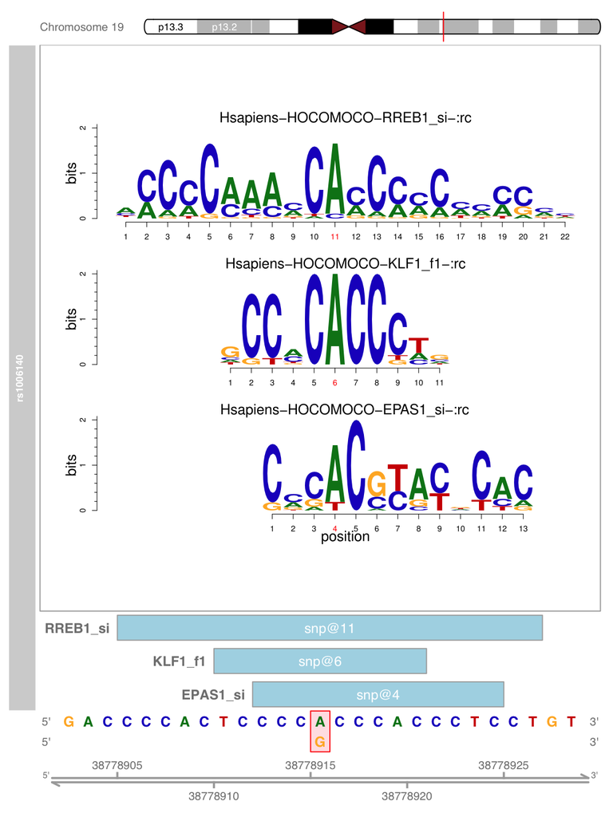

```r
plotMB(results = results, rsid = "rs1006140", effect = "strong")
```

# 4 Methods

*motifBreakR* works with position probability matrices (PPM). PPM are derived as the fractional occurrence of nucleotides A,C,G, and T at each position of a position frequency matrix (PFM). PFM are simply the tally of each nucleotide at each position across a set of aligned sequences. With a PPM, one can generate probabilities based on the genome, or more practically, create any number of position specific scoring matrices (PSSM) based on the principle that the PPM contains information about the likelihood of observing a particular nucleotide at a particular position of a true transcription factor binding site. What follows is a discussion of the three different algorithms that may be employed in calls to the *motifBreakR* function via the `method` argument.

Suppose we have a frequency matrix $M$ of width $n$ (*i.e.* a PPM as described above). Furthermore, we have a sequence $s$ also of length $n$, such that $s_{i} \in \{ A,T,C,G \}, i = 1,\ldots n$. Each column of $M$ contains the frequencies of each letter in each position.

Commonly in the literature sequences are scored as the sum of log probabilities:

## 4.1 Sum of Log Probabilities

$$F( s,M ) = \sum_{i = 1}^{n}{\log( \frac{M_{s_{i},i}}{b_{s_{i}}} )}$$

where $b_{s_{i}}$ is the background frequency of letter $s_{i}$ in the genome of interest. This method can be specified by the user as `method='log'`.

As an alternative to this method, we introduced a scoring method to directly weight the score by the importance of the position within the match sequence. This method of weighting is accessed by specifying `method='default'` (weighted sum). A general representation of this scoring method is given by:

## 4.2 Weighted Sum

$$F( s,M ) = p( s ) \cdot \omega_{M}$$

where $p_{s}$ is the scoring vector derived from sequence $s$ and matrix $M$, and $w_{M}$ is a weight vector derived from $M$. First, we compute the scoring vector of position scores $p$:

## 4.3 Calculating Scoring Vector $p$

$$p( s ) = ( M_{s_{i},i} ) \textrm{ where } \frac{i = 1,\ldots n}{s_{i} \in \{ A,C,G,T \}}$$

and second, for each $M$ a constant vector of weights $\omega_{M} = ( \omega_{1},\omega_{2},\ldots,\omega_{n} )$.

There are two methods for producing $\omega_{M}$. The first, which we call weighted sum, is the difference in the probabilities for the two letters of the polymorphism (or variant), *i.e.* $\Delta p_{s_{i}}$, or the difference of the maximum and minimum values for each column of $M$:

## 4.4 Calculating $\omega$ For Weighted Sum

$$\omega_{i} = \max \{ M_{i} \} - \min \{ M_{i} \}\textrm{ where }i = 1,\ldots n$$

The second variation of this theme is to weight by relative entropy. Thus the relative entropy weight for each column $i$ of the matrix is given by:

## 4.5 Calculating $\omega$ For Relative Entropy

$$\omega_{i} = \sum_{j \in \{ A,C,G,T \}}^{}{M_{j,i}\log_2( \frac{M_{j,i}}{b_{i}} )}\textrm{ where }i = 1,\ldots n$$

where $b_{i}$ is again the background frequency of the letter $i$.

Thus, there are 3 possible algorithms to apply via the `method` argument. The first is the standard summation of log probabilities (`method='log'`). The second and third are the weighted sum and information content methods (`method='default'` and `method='ic'`) specified by equations for Weighted Sum and Relative Entropy, respectively. *motifBreakR* assumes a uniform background nucleotide distribution ($b$) in equations 4.1 and 4.5 unless otherwise specified by the user. Since we are primarily interested in the difference between alleles, background frequency is not a major factor, although it can change the results. Additionally, inclusion of background frequency introduces potential bias when collections of motifs are employed, since motifs are themselves unbalanced with respect to nucleotide composition. With these cautions in mind, users may override the uniform distribution if so desired. For all three methods, *motifBreakR* scores and reports the reference and alternate alleles of the sequence ($F( s_{\textrm{REF}},M )$ and $F( s_{\textrm{ALT}},M )$), and provides the matrix scores $p_{s_{\textrm{REF}}}$ and $p_{s_{\textrm{ALT}}}$ of the SNP (or variant). The scores are scaled as a fraction of scoring range 0-1 of the motif matrix, $M$. If either of $F( s_{\textrm{REF}},M )$ and $F( s_{\textrm{ALT}},M )$ is greater than a user-specified threshold (default value of 0.85) the SNP is reported. By default *motifBreakR* does not display neutral effects, ($\Delta p_{i} < 0.4$) but this behaviour can be overridden.

## 4.6 Calculate P-values for PWM match

Additionally, now, with the use of *[TFMPvalue](http://cran.fhcrc.org/web/packages/TFMPvalue/index.html)*, we may filter by p-value of the match. This is unfortunately a two step process. First, by invoking `filterp=TRUE` and setting a threshold at a desired p-value e.g 1e-4, we perform a rough filter on the results by rounding all values in the PWM to two decimal place, and calculating a scoring threshold based upon that. The second step is to use the function `calculatePvalue()` on a selection of results which will change the `Refpvalue` and `Altpvalue` columns in the output from `NA` to the p-value calculated by `TFMsc2pv`. This can be (although not always) a very memory and time intensive process if the algorithm doesn’t converge rapidly.

[^1]: Website: [encode-motifs](http://compbio.mit.edu/encode-motifs/) Paper: [Systematic discovery and characterization of regulatory motifs in ENCODE TF binding experiments](http://dx.doi.org/10.1093/nar/gkt1249)
[^2]: Website: [Factorbook](http://factorbook.org/mediawiki/index.php/Welcome_to_factorbook) Paper: [Sequence features and chromatin structure around the genomic regions bound by 119 human transcription factors](http://dx.doi.org/10.1101/gr.139105.112)
[^3]: Website: [HOCOMOCO](http://autosome.ru/HOCOMOCO/) Paper: [HOCOMOCO: a comprehensive collection of human transcription factor binding sites models](http://dx.doi.org/10.1093/nar/gks1089)
[^4]: Website: [Homer](http://homer.salk.edu/homer/index.html) Paper: [http://www.sciencedirect.com/science/article/pii/S1097276510003667](http://dx.doi.org/10.1016/j.molcel.2010.05.004)